# **Python 🐍**

### **面向对象编程 (Object Oriented Programming)**

Python 支持多种编程范式, 包括过程式编程(procedural)、函数式编程(functional)和面向对象编程(object-oriented programming, OOP)。其中, 理解 Python 的**面向对象特性**是高效使用这门语言的关键。

> 在 Python 中，**一切皆对象** —— 无论是整数、字符串，还是函数，甚至类本身，都是对象。**对象是类(classes)的实例, 封装了属性(data/state)和行为(methods/functions)**。这种结构使得对象之间能够以可预测、模块化的方式进行交互，从而更容易设计、扩展和维护复杂的系统。

### **一些主要的操作符**

| **运算符** | **描述说明** | **示例** | **输出结果** |
| --- | --- | --- | --- |
| `=` | 赋值运算符 | `x = 5` | `x` 的值现在是 `5` |
| `+` | 加法 | `2 + 3` | `5` |
| `-` | 减法 | `5 - 2` | `3` |
| `*` | 乘法 | `4 * 2` | `8` |
| `/` | 除法（返回浮点数） | `5 / 2` | `2.5` |
| `//` | 整除（向下取整） | `5 // 2` | `2` |
| `%` | 取余（模运算） | `5 % 2` | `1` |
| `**` | 幂运算（指数） | `2 ** 3` | `8` |
| `@` | 矩阵乘法（如用于 NumPy 矩阵对象） | `A @ B` | 矩阵结果 |

### **一些主要的比较/逻辑运算符**

| **运算符** | **类型** | **描述说明** | **示例** | **输出结果** |
| --- | --- | --- | --- | --- |
| `==` | 比较运算符 | 判断两个值是否相等 | `5 == 5` | `True` |
| `!=` | 比较运算符 | 判断两个值是否不相等 | `5 != 3` | `True` |
| `>` | 比较运算符 | 判断左边是否大于右边 | `5 > 3` | `True` |
| `<` | 比较运算符 | 判断左边是否小于右边 | `2 < 4` | `True` |
| `>=` | 比较运算符 | 判断左边是否大于等于右边 | `5 >= 5` | `True` |
| `<=` | 比较运算符 | 判断左边是否小于等于右边 | `3 <= 3` | `True` |
| `and` | 逻辑运算符 | **逻辑与**，两个条件都为 True 时返回 True | `True and False` | `False` |
| `or` | 逻辑运算符 | **逻辑或**，任一条件为 True 时返回 True | `False or True` | `True` |
| `not` | 逻辑运算符 | **逻辑非**，将 True 变为 False，反之亦然 | `not True` | `False` |

```python
#@title 做些尝试！

my_var = 5 + 6
another_var = "Hello World！！！"

next_var = my_var ** 2
next_var += my_var

# next_var + another_var
another_var + "UCL is better than LSE"

many_things = [x for x in range(0, 10, 2)]
many_things

type(my_var)
isinstance(another_var, str)
```

```
True
```

### **比较运算符**

| **Operator** | **Description** | **Example** | **Output** |
| --- | --- | --- | --- |
| `==` | Equal to | `3 == 3` | `True` |
| `!=` | Not equal to | `3 != 2` | `True` |
| `>` | Greater than | `3 > 2` | `True` |
| `<` | Less than | `2 < 3` | `True` |
| `>=` | Greater than or equal to | `3 >= 3` | `True` |
| `<=` | Less than or equal to | `2 <= 3` | `True` |

```python
3 == "3" #False
3 == 3.000 #Ture
```

### **Python 主要的数据容器**

Python 提供了几种内建的数据容器, 帮助你高效地存储和组织数据。对于初学者来说, 最常见的四种是: 列表(list)、字典(dictionary)、元组(tuple)和集合(set)。

- **列表** (`[]`): **有序的、可变的元素集合。** 列表可以包含不同类型的元素，创建后可以修改、添加或删除其中的内容。 示例: `my_list = [1, 'apple', True]`
- **字典** (`{}`): **无序的键-值对集合。** 每个键(key)必须唯一，字典用于通过键快速查找或存储数据. 示例: `my_dict = {'name': 'Trump', 'age': 78}`
- **元组** (`()`): **有序的、不可变的元素集合。** 与列表类似，元组可以存储多种类型的值，但创建后内容不可更改。 示例: `my_tuple = (10, 'banana', False)`
- **集合** (`{}`): **无序的、唯一元素的集合。** 集合自动去除重复值，适用于进行成员测试或消除冗余数据的场景。 示例: `my_set = {1, 1, 2, 3} → {1, 2, 3}`

这些数据容器各有优势，掌握它们的使用场景是编写简洁高效 Python 代码的关键一步。

| 数据容器 | 符号 | 是否有序 | 是否可变 | 是否支持重复 | 典型用途 | 示例 |
| --- | --- | --- | --- | --- | --- | --- |
| 列表 (List) | `[]` | 是 | 可变 | 支持 | 存储可变的有序数据集合 | `[1, 'apple', True]` |
| 字典 (Dictionary) | `{}` | 否 | 可变 | 键唯一 | 以键访问数据，查找快 | `{'name': 'Trump', 'age': 78}` |
| 元组 (Tuple) | `()` | 是 | 不可变 | 支持 | 存储不可变的有序数据 | `(10, 'banana', False)` |
| 集合 (Set) | `{}` | 否 | 可变 | 不支持 | 去重、测试成员资格 | `{1, 1, 2, 3} → {1, 2, 3}` |

```python
#@title Example List
my_list = [1, 1, 2, 3, 5, 8]

my_list.append(6)
my_list

my_list_sqrd = [x**2 for x in my_list]
my_list_sqrd


my_list = [el for el in range (0, 20)]
my_list = [el for el in range (0, 20, 2)] #以2为间隔（即print 偶数）
my_list

my_list.append("Hello World")
my_list
```

```
[0, 2, 4, 6, 8, 10, 12, 14, 16, 18, 'Hello World']
```

```python
#@title Example Dictionary
ex_dict = {
    "a": 5,
    "b": 6,
    "c": [1, 2, 3]
}

ex_dict.items()
ex_dict.keys()
ex_dict.values()

ex_dict.get("a", 0)
ex_dict.get("d", 0)

ex_dict['a']
ex_dict['d'] = 4.5
```

### **Python 索引机制 (Indexing)**

在 Python 中, 索引是访问数据容器中单个元素的方式, 适用于列表(list)、元组(tuple)、字符串(string)和字典(dictionary)等数据结构。

Python 使用从 0 开始的索引(zero-based indexing), 也就是说:

- 第一个元素的位置是 0, 第二个是 1, 依此类推。
- 同时，你也可以使用**负索引(negative indexing)**从序列的末尾开始计数，其中 -1 表示最后一个元素。

列表、元组、字符串 等顺序类型(sequences)使用位置索引(positional indexing), 索引必须是整数。

- 如果访问一个不存在的索引位置，将会引发索引错误 (IndexError)。

与此不同, 字典(dictionary)使用的是键索引(key-based indexing), 而不是位置索引。 你通过键来访问对应的值，而不是通过数字位置。

| 数据类型 | 索引类型 | 是否有顺序 | 支持负索引 | 索引是否为整数 | 示例 |
| --- | --- | --- | --- | --- | --- |
| 列表 (List) | 位置索引 | 是 | 是 | 是 | `my_list[0]`, `my_list[-1]` |
| 元组 (Tuple) | 位置索引 | 是 | 是 | 是 | `my_tuple[1]`, `my_tuple[-2]` |
| 字符串 (String) | 位置索引 | 是 | 是 | 是 | `'hello'[0]`, `'hello'[-1]` |
| 字典 (Dict) | 键索引（key） | 否 | 否 | 否（使用键） | `my_dict['name']` |
| 集合 (Set) | 不支持索引 | 否 | 否 | 否 | ❌ 不支持直接索引访问 |

```python
#@title Indexing Example

my_list[0] # 第一个元素
my_list[1] # 第二个元素
my_list[-1] # 最后一个元素

ex_dict['a'] # 索引键 “a” 对应的值

my_list = ['a', 'b', 'c']
print(my_list[0])   # 输出: 'a'
print(my_list[-1])  # 输出: 'c'

my_dict = {'name': 'Trump', 'age': 78}
print(my_dict['name'])  # 输出: 'Trump'
```

```
a
c
Trump
```

### **Python 切片 (Slicing)**

**切片是从序列中访问一部分元素的方式** 适用于列表(list)、元组(tuple)和字符串(string)等序列类型。

基本语法是: `sequence[start:stop]`

- 返回从 start 索引开始、到 stop 索引之前(不包括 stop)的一个新子序列。
- 注意：切片中的 stop 是“左闭右开”的，即包括起始，不包括结束。

你还可以加入步长参数, 语法是: `sequence[start:stop:step]`

- step 表示每次移动多少个索引单位，默认是 1。
- step 可以为负值，这样就可以实现反向切片。

```python
#@title Slicing Example
my_list = [0, 1, 2, 3, 4, 5]

print(my_list[1:4])      # 输出 [1, 2, 3]
print(my_list[:3])       # 输出 [0, 1, 2]
print(my_list[::2])      # 输出 [0, 2, 4]
print(my_list[::-1])     # 输出 [5, 4, 3, 2, 1, 0]，反转列表
```

```
[1, 2, 3]
[0, 1, 2]
[0, 2, 4]
[5, 4, 3, 2, 1, 0]
```

### **成员关系与对象身份 (Membership & Identity)**

在 Python 中，我们经常使用以下两个运算符来判断对象之间的关系或内存身份：

| **运算符** | **作用说明** | **示例** | **输出结果** |
| --- | --- | --- | --- |
| `in` | 成员运算符, 判断一个元素是否存在于容器中 | `'a' in 'cat'` | `True` |
| `is` | 身份运算符, 判断两个变量是否引用同一个对象(内存地址) | `a is b` | `True` or `False` |

**🔍 拓展说明：**

- in 可以用于列表、字符串、元组、字典（对键）等容器类型：

```python
3 in [1, 2, 3]       # True
'key' in {'key': 1}  # True
```

- is 是检查两个变量是否是同一个对象 (即 id(a) == id(b))

```python
a = [1, 2]
b = a
c = [1, 2]

a is b  # True
a is c  # False（内容相同，但不是同一个对象）
```

### **For 与 While 循环 (For and While Loops)**

循环语句让你可以重复执行一段代码块, 是实现自动化、遍历数据和控制流程的重要工具。Python 中最常用的两种循环结构是: for 循环 和 while 循环。

**🔁 for 循环**

当你需要遍历 (iterate)一个序列（如列表、字符串或数字范围）时使用 for 循环。

```python
for item in [1, 2, 3]:
    print(item)
```

output:

```python
1
2
3
```

**🔁 while 循环**

当你不确定需要循环多少次，仅知道某个条件为真时要循环时，使用 while 循环。

```python
x = 0
while x < 3:
    print(x)
    x += 1
```

output:

```python
0
1
2
```

**🔑 Python 中的循环关键字(保留字):**

`for`, `while`, `in`, `break`等，是 Python 语言的保留关键字(reserved keywords), 具有特殊含义, 不能用作变量名:

| 特性 | `for` 循环 | `while` 循环 |
| --- | --- | --- |
| 用途 | 遍历序列（list、tuple、string、range 等） | 在某个条件为真时反复执行 |
| 是否需要初始化变量 | 否（自动从序列中取值） | 是（通常需要初始化计数器变量） |
| 适用场景 | 已知迭代次数、处理集合数据 | 条件控制循环，如等待用户输入、监测状态等 |
| 是否需指定终止条件 | 否（由序列长度决定） | 是（显式指定条件） |
| 可用关键词 | `for`, `in`, `break`, `continue` | `while`, `break`, `continue` |
| 可否无限循环 | 否（除非使用 `while True` 的等价写法） | 可以 (`while True:` 创建死循环) |

### **条件语句(Conditional Statements)**

条件语句允许程序**根据条件是否成立来决定执行哪一段代码**。这让你的程序能够进行“判断”和“分支”。

🔒 基本结构说明：

- `if`判断一个条件是否为真,若为真，则执行对应代码块。
- `elif` (“else if”的缩写) 如果前面的 if 条件为假，尝试判断另一个条件。
- `else` 如果以上所有条件都为假,则执行这一部分代码。

| 关键词 | 中文释义 | 用途说明 | 示例 |
| --- | --- | --- | --- |
| `if` | 如果 | 判断条件是否为真，执行代码块 | `if x > 0:` |
| `elif` | 否则如果 | 上一个条件为假时，检查另一个条件 | `elif x == 0:` |
| `else` | 否则 | 所有条件都为假时执行 | `else:` |

```python
#@title Example Conditional Statement
x = 10

if x > 15:
    print("x is greater than 15")
elif x > 5:
    print("x is greater than 5 but not more than 15")
else:
    print("x is 5 or less")
```

```
x is greater than 5 but not more than 15
```

**🌟小拓展：嵌套条件语句 (Nested if)与三元表达式 (One-liner if)**

**嵌套条件语句 (Nested if)**: 是指在一个 if 或 else 的代码块中，再写一个 if 判断，用于处理更复杂的决策逻辑。

```python
x = 15

if x > 0:
    if x < 10:
        print("x 是一个小的正数")
    else:
        print("x 是一个较大的正数")
else:
    print("x 不是正数")
```

output:

```python
x 是一个较大的正数
```

**三元表达式 (One-liner if)**: 也叫条件表达式 (Ternary Expression), 是一种简洁写法，适合在一行中进行简单判断和赋值。

```python
#语法格式：
变量 = 表达式1 if 条件 else 表达式2
```

```python
#示例
x = 5
result = "正数" if x > 0 else "非正数"
print(result)   # 输出：正数
```

### **逻辑运算符 (Logical Operators)**

| 运算符 | 描述说明 | 示例 | 输出结果 |
| --- | --- | --- | --- |
| `and` | 逻辑与（AND） | `True and False` | `False` |
| `or` | 逻辑或（OR） | `True or False` | `True` |
| `not` | 逻辑非（NOT） | `not True` | `False` |

**真值表（True Table）举例**

```python
# AND 示例
print(True and True)     # True
print(True and False)    # False

# OR 示例
print(False or True)     # True
print(False or False)    # False

# NOT 示例
print(not False)         # True
```

```python
#@title Example Logical Operators

age = 20
has_id = True

if age >= 18 and has_id:
    print("Access granted")
else:
    print("Access denied")
```

```
Access granted
```

### **函数 (Function)**

函数是**可以重复使用的代码块**，用于执行特定任务。使用函数可以帮助你更好地组织代码、实现复用、提升可读性和维护性。

```python
# define function
def greet(name):
    return f"Hello, {name}!"

# call function
greet("Leon")  # Output: 'Hello, Leon!'
```

```python
#@title Example Function

students = {
    "John": {"age": 20,
            "has_id": False},
    "Cook": {"age": 17,
            "has_id": True},
    "Ternus": {"age": 31,
               "has_id": True}
}

# IMPORTANT: INDENTATION!!!
def check_id(students: dict):
    for student in students.keys():
        age = students[student].get("age")
        id = students[student].get("has_id")

        if age >= 18 and id:
            print(f"{student}: access granted")
        else:
            print(f"{student}: no ")

check_id(students)
```

```
John: no
Cook: no
Ternus: access granted
```

**小练习**

请编写代码完成以下任务：

1. 创建一个包含从 10 到 40 的整数列表;
2. 对列表中的每个元素, 如果能被 5 整除，输出 “YAAY”;
3. 修改原列表，将可整除的元素替换为 “YAAY” 字符串
4. 封装成函数，适用于任何包含整数或浮点数的列表

```python
### Your Exercising Code ###


##
```

### **类的继承 (Class Inheritance)**

**继承（Inherence）**是面向对象编程中的核心概念之一，允许一个类（称为**子类**或**派生类**）继承另一个类（称为**父类**或**基类**）的属性和方法。

通过继承，子类可以重用父类已有的功能，同时添加或修改其行为，避免重复编写代码。

在 Python 中，通过在类定义的括号中传入父类名称来创建一个子类。如果子类需要自定义初始化过程，可以使用 `super()` 函数调用父类的 `__init__`方法，然后添加自己的属性或行为。

继承有助于保持代码的组织性，减少重复，并实现灵活、可扩展的程序设计。

```python
#@title Example Inheretance

class GraduateStudent(Student):
    def __init__(self, name, subject, grade, has_thesis):
        # Use super() to call the parent class's __init__ method
        super().__init__(name, subject, grade)
        self.has_thesis = has_thesis

    def is_doctor(self):
        # Graduate students need at least 70 to pass
        return self.grade >= 70 and self.has_thesis

anna = Student("Anna", "Python", 67)
bob = GraduateStudent("Bob", "AI Ethics", 72, True)
chris = GraduateStudent("Chris", "AI Ethics", 68, True)

print(anna.has_passed())   # True (Student needs 51)
print(bob.has_passed())    # True (Student needs 51)
print(chris.has_passed())  # True (Student needs 51)

print(bob.is_doctor())    # True (Graduate needs 70 + thesis)
print(chris.is_doctor())  # False (68 is not enough)
```

[output not shown]

[output not shown]

### **模块（Modules）**

在 Python 中，**模块是包含可重用代码的文件** —— 通常包括函数、变量或类 —— 可以在其他 Python 脚本中导入并使用。模块有助于你从逻辑上组织代码，使程序保持简洁和模块化。你可以使用内建模块（如 math、random 或 datetime），也可以创建你自己的模块。

**📐数学模块**

```python
import math

print(math.sqrt(16))        # 输出：4.0
print(math.pi)              # 输出：3.141592653589793
```

**🔢随机数模块**

```python
import random

print(random.randint(1, 1000))    # 输出：1 到 1000 之间的随机整数
print(random.choice(['A', 'B', 'C']))  # 从列表中随机选择一个元素
```

## **NumPy**

[figure not shown]

numpy.png.webp

在使用大型数据集或进行数值计算时，**性能至关重要**。Python 中的标准数据容器（如列表）虽然灵活且易于使用，但在进行大量数学运算时会变得低效。

这时就要引入 **NumPy —— 一个强大的库，它引入了一种高性能的数据容器 ndarray（n维数组）**。 与 Python 的列表不同，ndarray 是专为数值计算设计的。它提供了更快的计算速度、更低的内存占用，并具备便捷的语法来进行数组操作、线性代数和统计计算。

数据科学和机器学习领域中的大多数主流库 —— 包括 Pandas、Matplotlib 和 Scikit-learn —— 都是建立在 NumPy 之上的。因此，学习 NumPy 是进入更高级工具和工作流的基础步骤。

### **NumPy好在哪里？**

Python 是动态类型语言（dynamically typed），意味着你不需要声明变量的类型 —— Python 会自动推断。虽然这让 Python 非常易读且灵活，但也带来了额外的开销（Overhead）：列表中的每个元素都是一个完整的 Python 对象，携带着如类型、内存引用等元数据。

对于小型任务，这种开销可以忽略不计。但在进行大规模数值运算时，这种开销会成为性能瓶颈 —— 导致运算更慢、内存占用更高。

> NumPy 通过其 ndarray 解决了这个问题，它是静态类型的数组容器 —— 所有元素都以相同的数据类型（如 float64）连续存储在内存中。这意味着：
- 不需要多余的类型检查；
- 每个元素不再单独存储类型元数据（type metadata）；
- 访问和运算速度更快（得益于底层的 C 语言实现）。

简而言之：**NumPy 用牺牲一部分灵活性换来了巨大的速度与效率提升**，使其成为 Python 中进行高性能数值计算的首选工具。

```python
import numpy as np # np 是 NumPy 的标准别名（alias）
```

```python
np.array([1, 2, 3])
```

```
array([1, 2, 3])
```

```python
#@title Difference between python list and an np ndarray

example_list = list(range(1_000_000))

example_array = np.arange(1_000_000)

# mutiply each element by 2
%timeit example_list_multipled = [e * 2 for e in example_list]
%timeit example_array_multiplied = example_array * 2
```

```
65.1 ms ± 13.6 ms per loop (mean ± std. dev. of 7 runs, 10 loops each)
1.2 ms ± 79.8 µs per loop (mean ± std. dev. of 7 runs, 1000 loops each)
```

### **ndarray：NumPy 的核心数据结构**

> **数组是一种用于存储和访问数据的结构。** 你可以把数组想象成一个空间中的网格，每个“格子”中存储一个数据元素。

一个 ndarray 拥有以下属性： - `ndim`: 数组的维度数量。 - `shape`: 每个维度上的元素个数（即数组的形状）。 - `size`: 数组中所有元素的总数。 - `dtype`: 数组中所有元素的数据类型。

```python
#@title Example Creating Arrays


# NumPy 创建不同类型的数组（arrays）的基本方法

# 从列表创建数组
my_list = [1, 2, 3]
my_arr = np.array(my_list)
my_arr

# 使用 np.arange() 创建范围数组
my_arr2 = np.arange(4)                    # similar to python list: my_list = list(range(4))
my_arr2                                   # 生成 [0, 1, 2, 3] 的数组（不包括上限 4），类似于 range() 函数

#固定值数组：全为 0
zeros = np.zeros((2, 5, 5))
zeros                                     # 创建2组 5x5的数组，所有值均为0，默认数据类型是 float64

#固定值数组：全为 1（指定形状 & 类型）
ones = np.ones((3, 3, 3), dtype=np.int16) # dtype=np.int16 指定数据类型为 16 位整数（可以省略）
ones                                      # 创建一个 3x3x3 的三维数组，所有元素都是 1

#固定值数组：自定义值
arr_custom = np.full((2), 7.645)          # 创建一个 长度为 2 的数组，所有元素都是 7.645
arr_custom
```

[output not shown]

### **数组的索引与切片（Indexing and Slicing Arrays）**

#### **一维数组（1D Arrays）**

要从数组中选择某个元素，使用方括号并通过索引指定所需元素的位置（从 0 开始计数）

一维数组的索引方式与 Python 列表类似:

```
array[index]
```

#### **二维数组（2D Arrays）**

对于多维数组，要获取某个元素，需要为数组的每一维提供一个索引。

对于二维数组（matrix），使用一对索引 `(row, column)` 来访问：

```
array[row, column]
```

#### **三维数组及更高维（3D Arrays 及以上）**

对于维度更高的数组，可以将“列索引”视为最后一维，“行索引”为倒数第二维。

```
array[:, :, row, column] # 示例：用于一个 4D 数组
```

```python
#@title Example Array Indexing

arr_2d = np.arange(27).reshape((9,3))  #创建一个数字从0到27，9行三列的矩阵
arr_2d

arr_2d[0, 0] # get first row first column value
arr_2d[0, -1] # last column of first row
arr_2d[1, ] # all of second row

arr_3d = np.arange(27).reshape((3,3,3))
arr_3d

arr_3d[1] # get second element of first dimension (matrix)
arr_3d[1, 1] # get second matrix, second row
arr_3d[:, -1, -1] # get second matrix, second row, third column value
```

[output not shown]

### **数组的切片（Slicing Arrays）**

要获取多个元素或子数组，我们仍然使用方括号（square brakets）和切片语法：

```
array[start:stop:step]
```

- `start` 起始索引（默认值为 0）
- `top` 终止索引（默认是该维度的长度，不包含该索引）
- `step` 步长（默认是 1）

如果将 `step` 设置为负值，`start` 和 `stop` 的默认值会被交换，这是一种**反转数组**的常见技巧。

> NumPy 的切片操作会创建数组的一个视图（view），而不是副本（copy）。这意味着对切片后的数组进行更改，会影响原数组中的对应部分。

| 操作 | 含义 | 示例 | 说明/备注 |
| --- | --- | --- | --- |
| `array[i, j]` | 访问第 i 行第 j 列的元素 | `a[1, 2]` | 用于二维或更高维数组索引 |
| `::2` | 步长为 2，隔一个取一个元素 | `a[::2]` | 用于切片，返回偶数索引的元素 |
| `[::-1]` | 倒序 | `a[::-1]` | 快速反转数组顺序 |
| `.copy()` | 显式复制数组 | `b = a.copy()` | 防止修改视图影响原数组 |
| `.reshape()` | 改变数组形状，不改变数据内容 | `a.reshape(2, 3)` | 新形状必须与元素数量匹配 |

```python
#@title Example Slicing Arrays

arr_2d = np.arange(27).reshape((3, 9))     # 创建一个从 0 到 26 的一维数组，重塑成 3 行 9 列的二维数组
arr_2d

arr_2d[1, :4] # 第 2 行（索引为 1），前 4 个元素
arr_2d[1, ::2] # 第 2 行，每隔一个取一个（步长为 2）
arr_2d[::2, ::2] # 每隔一行 & 每隔一列取一个，起点都是第 0 行/列

arr_2d[::-1, ] # 所有行反转（上下颠倒）

# view vs copy
second_row = arr_2d[1]  # 这并不是复制了第 2 行，而是创建了 一个对原数组的“视图”（view）
second_row

second_row[:2] = 999 # 注意！把视图中的前两个值改成了 999，原数组也会被修改！
second_row
arr_2d

#⚠️注意⚠️ NumPy 默认用“视图”而不是“复制”，这可以节省内存，但如果你要避免影响原数据，还是需使用 .copy()


# 创建三维数组
arr_3d = np.arange(27).reshape((3,3,3)) #创建一个形状为 (3,3,3) 的三维数组（3 个 3x3 的小矩阵）
arr_3d

arr_3d[1, 1, ::2] # 取第 2 个“矩阵”（索引为 1）它的第 2 行（索引为 1），这一行中，每隔一列取一个元素（步长为 2）
```

```
array([12, 14])
```

```python
#@title Exercises Array Manipulation

#### Your Code Here ####

# 1: 所有矩阵、所有行、第3列（索引2）
third_col = arr_3d[:, :, 2]

# 2: 第3个矩阵（索引2）、第2行（索引1）、所有列
second_row_third_matrix = arr_3d[2, 1, :]

# 3: 第1个矩阵（索引0）、最后一行（索引2）、中间列（索引1）
mid_val = arr_3d[0, 2, 1]

#输出结果
print("1️⃣ Third column of all matrices:\n", third_col)
print("2️⃣ Second row of third matrix:\n", second_row_third_matrix)
print("3️⃣ First matrix, last row, middle column:\n", mid_val)
```

```
1️⃣ Third column of all matrices:
 [[ 2  5  8]
 [11 14 17]
 [20 23 26]]
2️⃣ Second row of third matrix:
 [21 22 23]
3️⃣ First matrix, last row, middle column:
 7
```

### **高级索引（Advanced Indexing）**

“高级索引”（也称为“花式索引” fancy indexing）指的是使用数组对另一个数组进行索引的所有情况。**高级索引总是返回一个副本（copy），而不是原始数据的视图（view）。**

高级索引使你能够**快速地访问和修改数组中某些值的子集**，特别适用于按条件或特定索引位置提取多个元素。

```python
#@title Example Fancy Indexing
arr_2d = np.arange(15).reshape(5,3)
arr_2d

idx = [1,2]

arr_2d[idx] # select indexed rows
arr_2d[:, idx] # select indexed columns

rows = [0, 1]
cols = [1, 2]

arr_2d[rows, cols]
```

```
array([1, 5])
```

**NumPy 中的布尔索引操作符（Boolean Indexing Operators）**

| 操作符 | 操作类型 | 示例 | 描述说明 |
| --- | --- | --- | --- |
| `&` | 按位与（AND） | `(arr > 5) & (arr < 10)` | 元素级的逻辑与操作 |
| `\\|` | 按位或（OR） | `(arr < 3) \\| (arr > 8)` | 元素级的逻辑或操作 |
| `~` | 按位非（NOT） | `~(arr > 5)` | 反转布尔掩码（mask） |
| `!=` | 不等于 | `arr != 0` | 筛选不等于某值的元素 |
| `==` | 等于 | `arr == 10` | 筛选等于某值的元素 |
| `>` | 大于 | `arr > 5` | 筛选大于某值的元素 |
| `<` | 小于 | `arr < 5` | 筛选小于某值的元素 |
| `>=` | 大于或等于 | `arr >= 5` | 筛选大于或等于某值的元素 |
| `<=` | 小于或等于 | `arr <= 5` | 筛选小于或等于某值的元素 |

```python
#@title Example Fancy Idx (Boolean)
mask = arr_2d > 7
mask
# arr_2d[arr_2d > 7]
```

[output not shown]

### **数组上的操作（Operations on Arrays）**

数组非常强大，因为它们允许你不使用 for 循环就能进行批量操作。

**💡 通用函数（ufunc）**

通用函数（universal functions）是 NumPy 中的快速函数，可对数组中的数据逐元素执行操作。

> **向量化（Vectorisation）**是 NumPy 中的一种计算技巧，能在不显式写循环的情况下，对整个数组同时应用运算。

| 函数名 | 操作类型 | 示例 | 描述说明 |
| --- | --- | --- | --- |
| `np.add()` | 加法 | `arr1 + arr2` | 对应元素相加 |
| `np.subtract()` | 减法 | `arr1 - arr2` | 对应元素相减 |
| `np.multiply()` | 乘法 | `arr1 * arr2` | 对应元素相乘 |
| `np.divide()` | 除法 | `arr1 / arr2` | 对应元素相除 |
| `np.power()` | 幂运算 | `arr**2` | 每个元素的平方（或次方） |
| `np.sqrt()` | 开方 | `np.sqrt(arr)` | 每个元素开平方 |
| `np.exp()` | 指数 | `np.exp(arr)` | e 的每个元素次幂 |
| `np.abs()` | 绝对值 | `np.abs(arr)` | 每个元素取绝对值 |

汇总统计（Summary Statistics）：

| 函数名 | 操作类型 | 示例 | 描述说明 |
| --- | --- | --- | --- |
| `np.mean()` | 平均值 | `arr.mean()` | 计算算术平均值 |
| `np.median()` | 中位数 | `np.median(arr)` | 排序后取中间的值 |
| `np.std()` | 标准差 | `arr.std()` | 数据的离散程度（波动） |
| `np.var()` | 方差 | `arr.var()` | 每个元素与平均值的偏差平方的平均 |
| `np.sum()` | 总和 | `arr.sum()` | 所有元素相加 |
| `np.min()` | 最小值 | `arr.min()` | 数组中最小的元素 |
| `np.max()` | 最大值 | `arr.max()` | 数组中最大的元素 |

> 📚 想要了解更多？ - [NumPy ufuncs basics](https://numpy.org/doc/2.1/user/basics.ufuncs.html#ufuncs-basics) - [NumPy ufuncs](https://numpy.org/doc/2.1/reference/ufuncs.html#ufuncs)

```python
#@title Example Operations on Arrays

#1. 创建数组 & 简单加法
arr = np.arange(10)
arr + 5

#2. 反转数组并做对应元素相乘
arr2 = arr[::-1]
arr2

arr * arr2 # 将相应元素相乘

#3. 统计方法：平均值 & 标准差
arr.mean() # 均值

arr.std() # 标准差（std）：默认是总体标准差（denominator = n）
# arr.std(ddof=1) # 带贝塞尔修正的std

arr = arr.reshape(5,2)
arr

# arr.sum() # 所有元素求和
# arr.sum(axis = 1) # 沿着第1轴（列）求和，即对“每一行”求和
arr.sum(axis = 0) # 沿着第0轴（行）求和，即对“每一列”求和
```

```
array([20, 25])
```

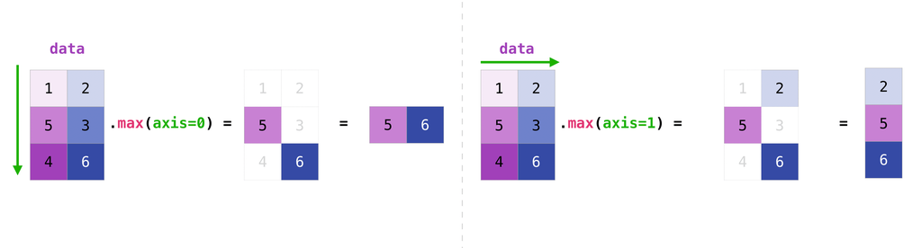

np_matrix_aggregation_row.png

[Img source: NumPy basics](https://numpy.org/doc/stable/user/basics.broadcasting.html)

### **广播机制（Broadcasting）**

假设你有两个形状不同的数组，但你想对它们执行某种操作（例如相加）。通常你需要将它们“变为相同形状”才能进行逐元素运算。

> **广播（Broadcasting）** 是 NumPy 用来扩展或复制较小数组形状的机制，从而使它们在逐元素操作（element-wise operations）时形状相容。

**✅ 两个维度在以下情况下被认为是兼容的：** 1. **两个维度相等，或** 2. **其中一个维度为 1**

**🔄 广播的工作方式：从右向左比较数组的形状维度** （即从最后一个维度开始，逐步向前比较）

**📢 广播的步骤详解：**

1. **对齐维度（Align Dims）**: 如果两个数组的维度数量不同，NumPy 会在较小数组的形状前补上 1，直到两者维度数一致。

```
a.shape = (3, 4, 5)
b.shape = (4, 5) → prepend 1 to make (1, 4, 5)
```

2. **检查兼容性（Check Compatibility）**: 对于每一个对应维度，满足以下任一条件即可广播： `1`. 两个维度值相等 `2`. 其中一个维度为 1（会自动“扩展”）

```
a.shape = (3, 4, 5)
b.shape = (1, 4, 5) broadcast to (3, 4, 5)
```

3. **完成操作（Element-wise Operation）**：如果所有维度都满足条件，两个数组就被广播为相同形状，可以进行逐元素操作（如加法、乘法等）。

参考: - [NumPy Broadcasting Explained (mCoding)](https://www.youtube.com/watch?v=oG1t3qlzq14&t=354s) - [NumPy Website on Broadcasting](https://numpy.org/doc/stable/user/basics.broadcasting.html)

```python
a = np.array([1,2,3])
b = 2
print(a.shape)
```

```
(3,)
```

```python
a * b
```

```
array([2, 4, 6])
```

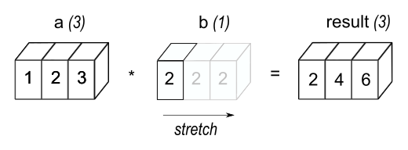

broadcasting_1.png

[Img source: NumPy broadcasting](https://numpy.org/doc/stable/user/basics.broadcasting.html)

```python
a = np.array([[0, 0, 0],
            [10, 10, 10],
            [20, 20, 20],
            [30, 30, 30]])

b = np.array([1, 2, 3])

print(a.shape, b.shape)
```

```
(4, 3) (3,)
```

```python
a + b # shapes: (4, 3) + (1, 3)
```

```
array([[ 1,  2,  3],
       [11, 12, 13],
       [21, 22, 23],
       [31, 32, 33]])
```

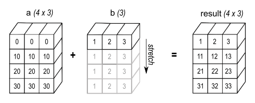

broadcasting_2.png

[Img source: NumPy broadcasting](https://numpy.org/doc/stable/user/basics.broadcasting.html)

```python
a = np.array([[0, 0, 0],
            [10, 10, 10],
            [20, 20, 20],
            [30, 30, 30]])

b = np.array([1, 2, 3, 4]) # added one more element!

print(a.shape, b.shape)
```

```
(4, 3) (4,)
```

```python
a + b # shapes: (4, 3) + (1, 4) will give error bc 3 and 4 not match
# a + b.reshape(-1, 1)
```

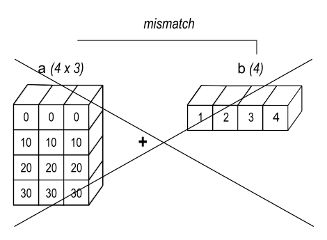

broadcasting_3.png

[Img source: NumPy broadcasting](https://numpy.org/doc/stable/user/basics.broadcasting.html)

```python
a = np.array([[0], [10], [20], [30]])

b = np.array([1, 2, 3])

print(a.shape, b.shape)
```

```
(4, 1) (3,)
```

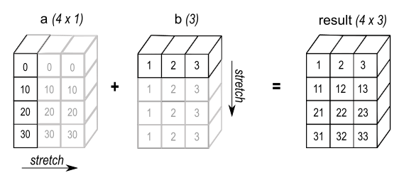

broadcasting_4.png

[Img source: NumPy broadcasting](https://numpy.org/doc/stable/user/basics.broadcasting.html)

```python
#@title Exercises NumPy

arr_2d = np.arange(27).reshape(3, -1)
print(arr_2d)

# 任务 1：对每列进行中心化（减去列的均值）
col_means = arr_2d.mean(axis=0)                    # 沿 axis=0（即列）计算均值
centered_by_column = arr_2d - col_means            # 对每一列的每个元素减去该列的均值
print("\n任务1：\n", centered_by_column)


# 任务 2：将每一行归一化（总和为 1）
row_sums = arr_2d.sum(axis=1, keepdims=True)       # 计算每一行的总和，保持列结构（用于广播）
normalized_by_row = arr_2d / row_sums              # 每行除以它自己的和，实现归一化
print("\n任务2：\n", normalized_by_row)


# 任务 3：将每个元素替换为它与数组整体均值的距离
overall_mean = arr_2d.mean()                       # 计算整个数组的均值
distance_from_mean = np.abs(arr_2d - overall_mean) # 使用 np.abs 计算每个元素与整体均值的绝对距离
print("\n任务3：\n", distance_from_mean)
```

```
[[ 0  1  2  3  4  5  6  7  8]
 [ 9 10 11 12 13 14 15 16 17]
 [18 19 20 21 22 23 24 25 26]]

任务1：
 [[-9. -9. -9. -9. -9. -9. -9. -9. -9.]
 [ 0.  0.  0.  0.  0.  0.  0.  0.  0.]
 [ 9.  9.  9.  9.  9.  9.  9.  9.  9.]]

任务2：
 [[0.         0.02777778 0.05555556 0.08333333 0.11111111 0.13888889
  0.16666667 0.19444444 0.22222222]
 [0.07692308 0.08547009 0.09401709 0.1025641  0.11111111 0.11965812
  0.12820513 0.13675214 0.14529915]
 [0.09090909 0.0959596  0.1010101  0.10606061 0.11111111 0.11616162
  0.12121212 0.12626263 0.13131313]]

任务3：
 [[13. 12. 11. 10.  9.  8.  7.  6.  5.]
 [ 4.  3.  2.  1.  0.  1.  2.  3.  4.]
 [ 5.  6.  7.  8.  9. 10. 11. 12. 13.]]
```